# CHRI subpopulation analysis: Real-world examples and more

2018 Eastern Regional Training Institute for SACs, JRSA

Bobae Kang, Illinois SAC

December 5, 2018

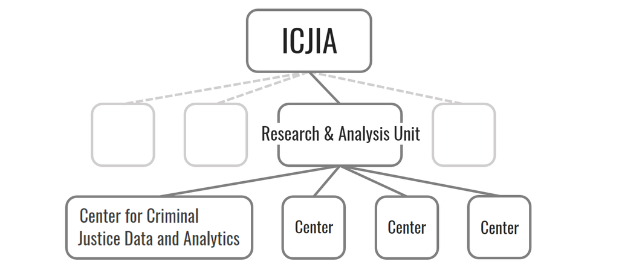

More on Illinois SAC: http://www.icjia.state.il.us/research/overview

## This presentation is . . .

- To share our experience, not establish rules
- Focused on study design, not results
- Opinionated, not neutral

  Slides available at https://bobaekang.github.io/jrsa2018eastern/slides

# Example 1: First-time firearm offenders

#2016-BJ-CX-K024

How do first-time firearm offenders  
behave differently?

## Highlights

- Sample construction
  - Coarsened exact matching
- Combining multiple data sources
  - More nuanced “time to event”

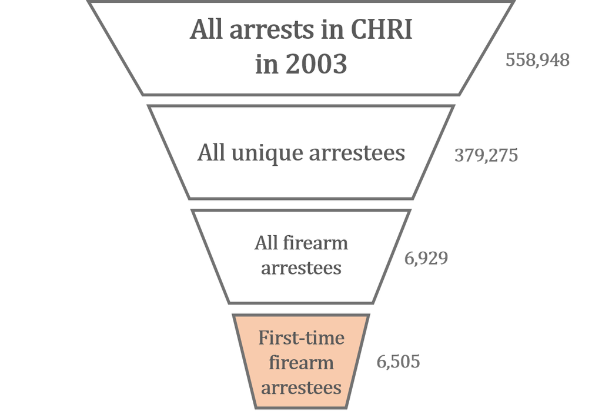

Example 1: Sample construction

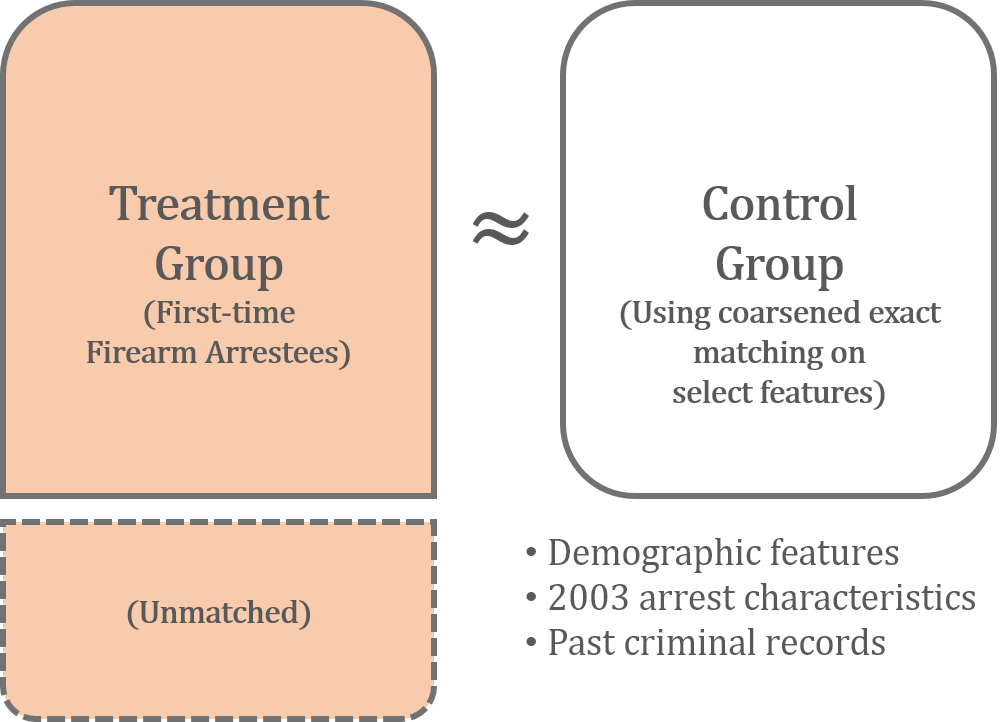

Example 1: Sample construction

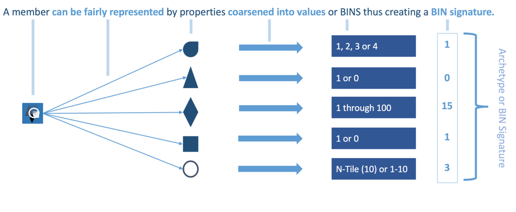

Example 1: Coersened exact matching ( [@devmotivation 2017](https://medium.com/@devmotivation/cem-coarsened-exact-matching-explained-7f4d64acc5ef) )

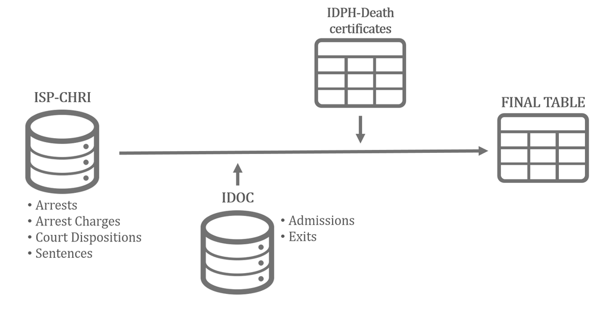

Example 1: Multiple data sources

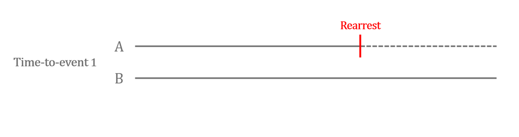

Example 1: Time to event

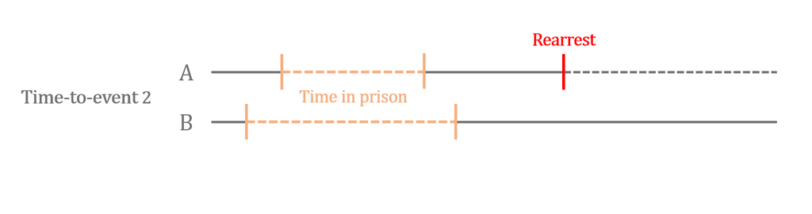

Example 1: Time to event

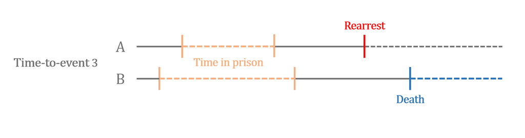

Example 1: Time to event

# Example 2: Registered sex offenders

#2017-BJ-CX-K016

To what extent the registry changes over time?  
Who are the registered sex offenders & what does their criminal history look like?

## Highlights

- Sex Offender Registry (SOR) table
- Combining multiple data sources
  - More nuanced “current residence”
  - “Criminal history analysis group”

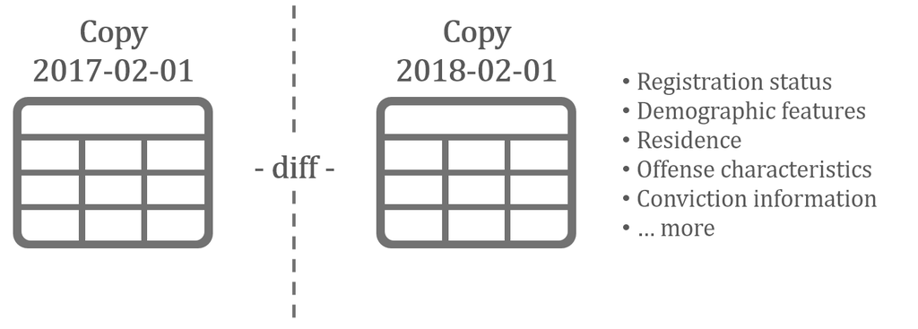

Example 2: SOR table

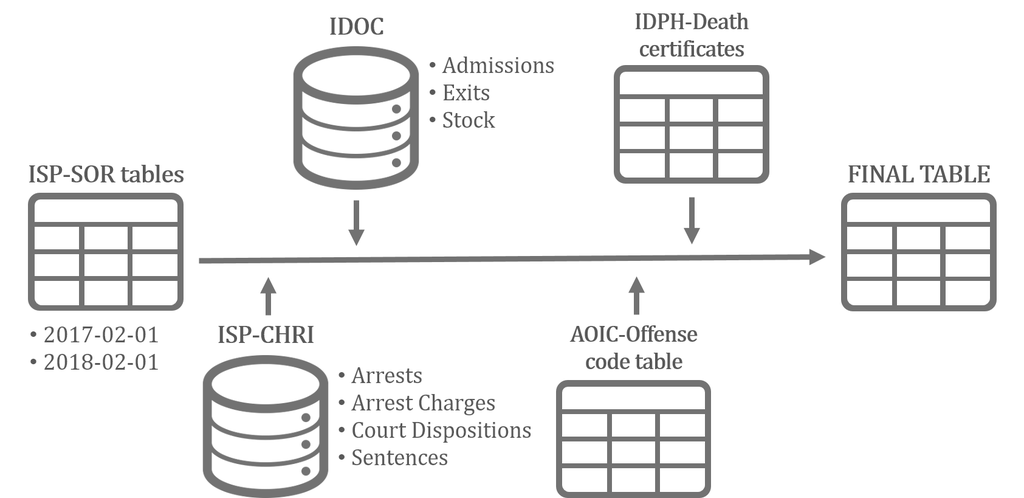

Example 2: Multiple data sources

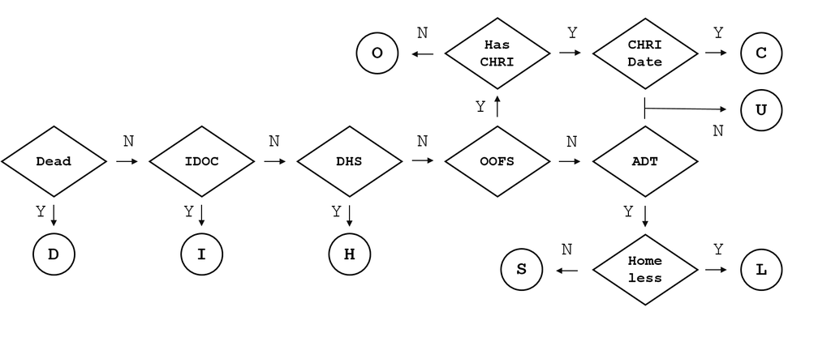

Example 2: Current residence

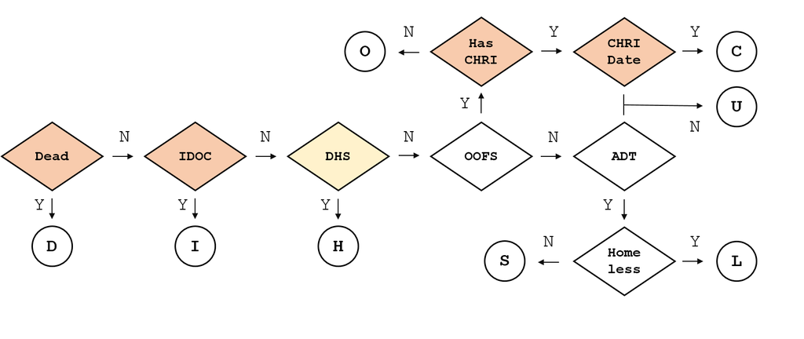

Example 2: Current residence

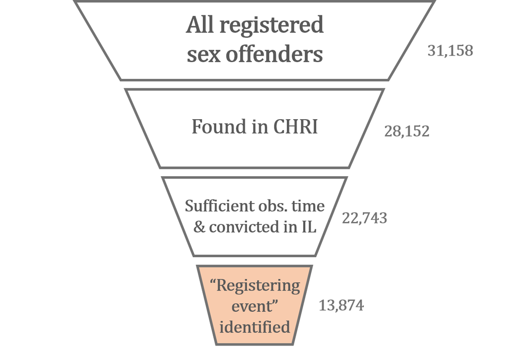

Example 2: Crinimal history analysis group

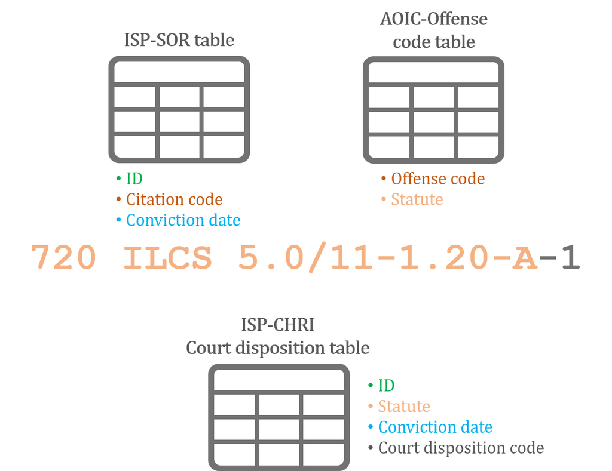

Example 2: Identifying the “registering event”

# Programmatic approach to research

A programmatic approach to research  
relies on *computer programs*  
to *organize* and *carry out*  
research tasks.

## Basic workflow

1. Set up a research project directory
2. Write and run computer programs to
   - obtain datasets
   - prepare clean datasets
   - conduct analyses
   - generate reports, slides, etc.
3. Share results

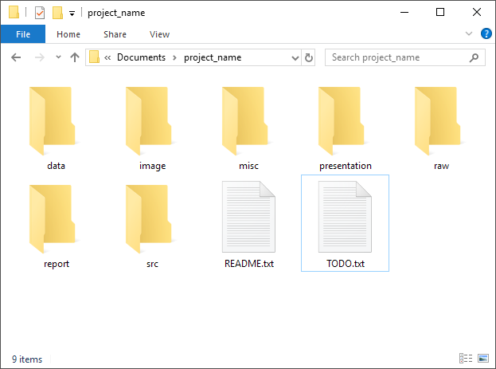

Research directory example

## Key benefits

- Automation
- Flexibility
- Reproducibility

[figure not shown]

# Thank you :)

References

- devmotivation. (2017, April 18). CEM: Coarsened Exact Matching Explained [Medium]. Retrieved from https://medium.com/@devmotivation/cem-coarsened-exact-matching-explained-7f4d64acc5ef
- Iacus, S., King, G., & Porro, G. (n.d.). CEM: Coarsened Exact Matching Software. Retrieved from https://gking.harvard.edu/cem
- Morgan, S. & Winship, C. (2015). *Counterfactuals and Causal Inference: Methods and Principles for Social Research* (2nd ed.). New York, NY: Cambridge University Press.

Slides  
https://bobaekang.github.io/jrsa2018eastern/slides  
ICJIA R Workshop resources  
https://bobaekang.github.io/icjia-r-workshop/